# Tugas Pertemuan 5

## Cek Lagi Stationer atau Tidak

#### Plot ACF

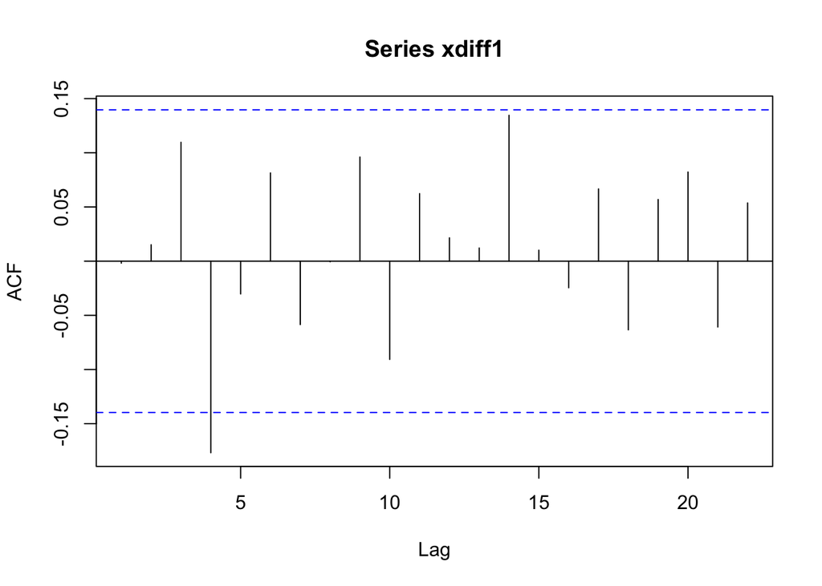

```r
acf(xdiff1)
```

Dari plot ACF tampak bahwa pola autokorelasi tidak lagi menurun secara lambat, sehingga hal ini mengindikasikan bahwa data telah mencapai kestasioneran pada rataan.

#### Uji ADF

```r
tseries::adf.test(xdiff1)
```

```
##
##  Augmented Dickey-Fuller Test
##
## data:  xdiff1
## Dickey-Fuller = -5.6911, Lag order = 5, p-value = 0.01
## alternative hypothesis: stationary
```

𝐻0 : Data tidak stasioner dalam rataan

𝐻1 : Data stasioner dalam rataan

Hasil uji ADF menunjukkan nilai p sebesar 0,01, yang lebih kecil dibandingkan taraf signifikansi 5%. Dengan demikian, 𝐻0 ditolak dan dapat disimpulkan bahwa data sudah stasioner pada rataan, sejalan dengan temuan dari plot deret waktu maupun ACF.

#### Plot Box Cox

```r
index <- seq(1:length(xdiff1))

# Uji Box-Cox
bc <- boxcox(
  xdiff1 - min(xdiff1) + 1 ~ index,
  lambda = seq(-4, 6, by = 0.01)
)
```

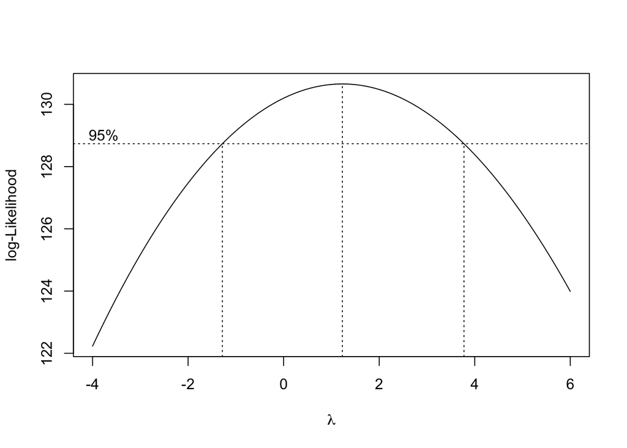

```r
# Nilai lambda optimum
lambda <- bc$x[which.max(bc$y)]
lambda
```

```
## [1] 1.23
```

```r
# Selang kepercayaan 95% untuk lambda
ci_lambda <- bc$x[bc$y > max(bc$y) - 0.5 * qchisq(0.95, 1)]

# Batas bawah dan batas atas
ci_lower <- min(ci_lambda)
ci_upper <- max(ci_lambda)

c(Batas_Bawah = ci_lower, Batas_Atas = ci_upper)
```

```
## Batas_Bawah  Batas_Atas
##       -1.28        3.77
```

Dari hasil estimasi, diperoleh nilai 𝜆 optimum sekitar 1,23 dengan interval kepercayaan 95% antara -1,28 hingga 3,77. Karena rentang tersebut mencakup angka 1, maka dapat disimpulkan bahwa data sudah memenuhi asumsi kestasioneran dalam ragam.

## Identifikasi Model

#### Plot ACF, PACF, EACF

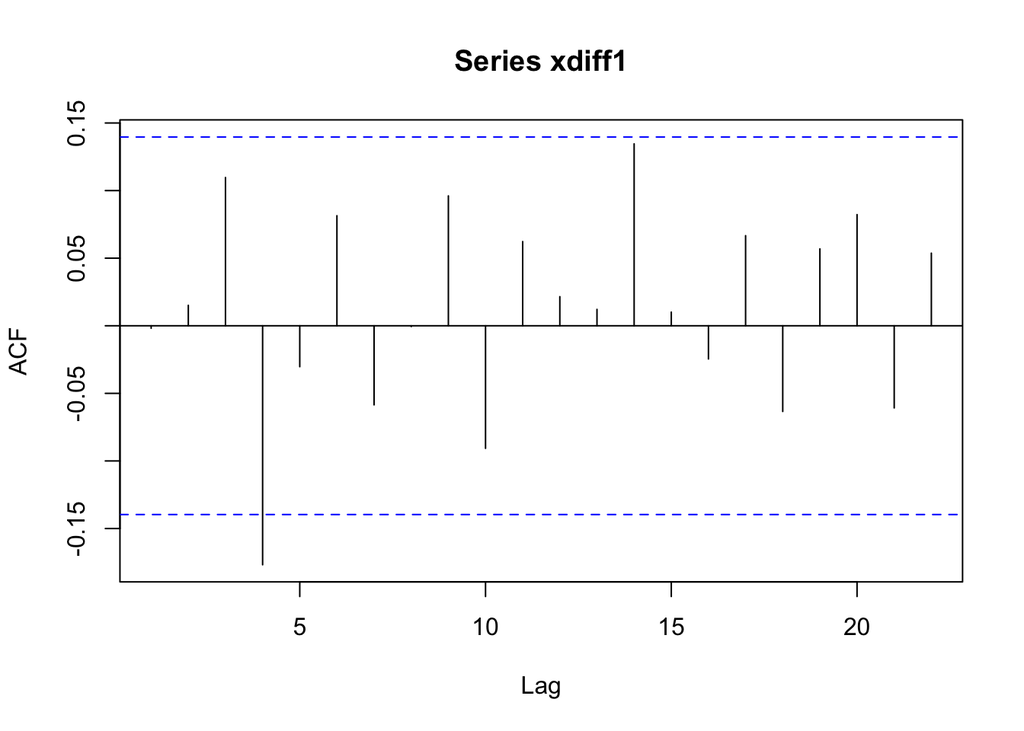

```r
acf(xdiff1)
```

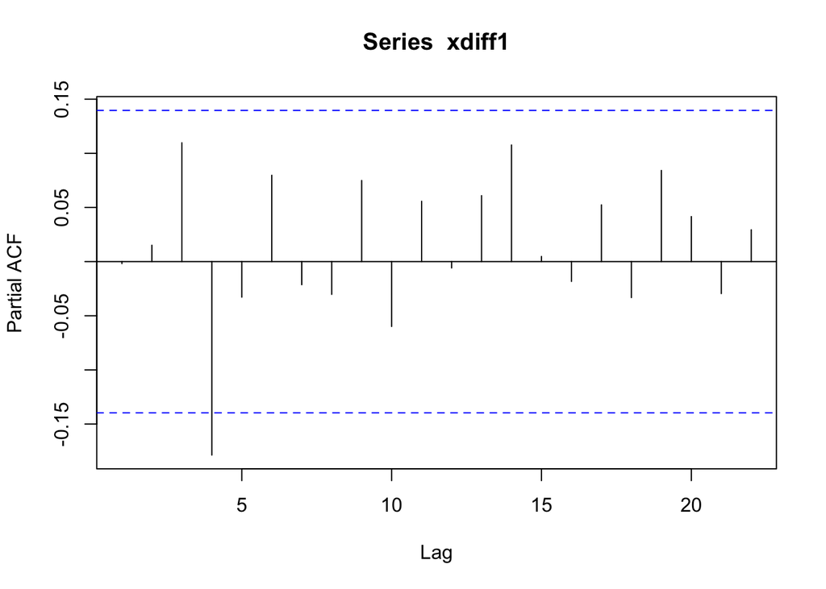

```r
pacf(xdiff1)
```

```r
eacf(xdiff1)
```

```
## AR/MA
##   0 1 2 3 4 5 6 7 8 9 10 11 12 13
## 0 o o o x o o o o o o o  o  o  o
## 1 o o o x o o o o o o o  o  o  o
## 2 o o o o o o o o o o o  o  o  o
## 3 x x x x o o o o o o o  o  o  o
## 4 x x x o o o o o o o o  o  o  o
## 5 x x x o o o o o o o o  o  o  o
## 6 x x o o o o o o o o o  o  o  o
## 7 x x x o o o o o o o o  o  o  o
```

**Model tentatif (urut dari yang paling konsisten dgn EACF)**